# Spotify2_V6

### QDA : Quadratic linear analysis

#### Matrice de confusion :

```r
qda_T_H<-qda(popularity~., data=train_data_H)
res_qda_T_H<-predict(qda_T_H,newdata = valid_data_H)
prediction_qda_T_H<-res_qda_T_H$class
Realite_qda_T_H<-valid_data_H$popularity
MatConf_qda_T_H<-table(Realite_qda_T_H, prediction_qda_T_H)

round(prop.table(table(Realite_lda_T_H,prediction_qda_T_H),margin=1)*100,1)%>%kable(caption = "QDA_T : matrice de confusion seuil 0,5")%>% kable_styling()
```

QDA_T : matrice de confusion seuil 0,5

|  | haute | basse |
| --- | --- | --- |
| haute | 40.2 | 59.8 |
| basse | 13.8 | 86.2 |

#### Choix du meilleur seuil :

Evolution des 3 types d’erreur en fonction de l’évolution du seuil :

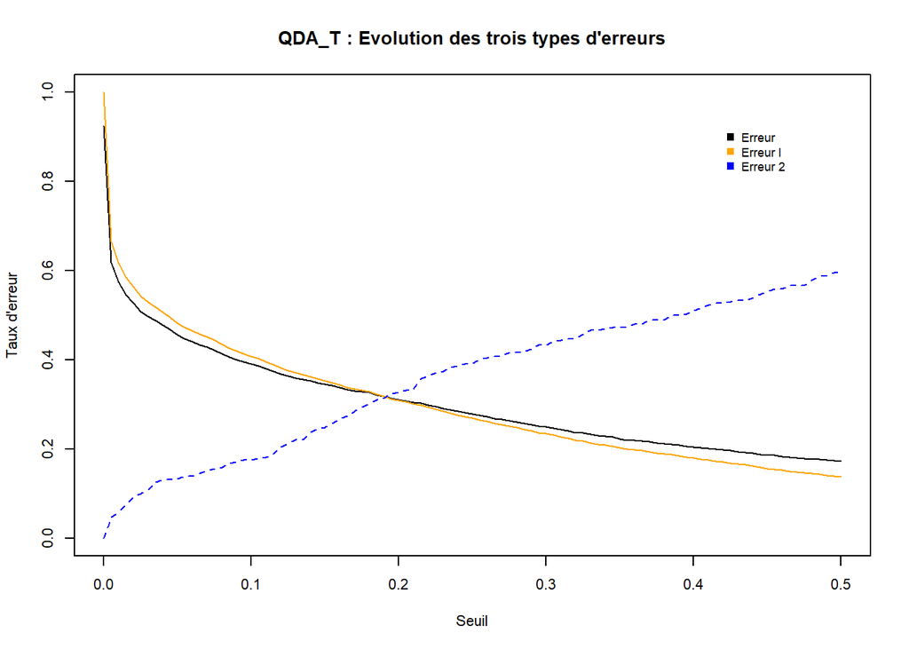

```r
N<-sum(valid_data_H=="basse")
P<-sum(valid_data_H=="haute")
Error_qda_T_H<-NULL
ErrorI_qda_T_H<-NULL
ErrorII_qda_T_H<-NULL
for(i in 1:101){
c<-(i-1)/200
Prediction_qda_T_H<-rep("basse",nrow(valid_data_H))
Prediction_qda_T_H[res_qda_T_H$posterior[,1]>c]<-"haute"
Error_qda_T_H[i]<-sum(Prediction_qda_T_H!=Realite_qda_T_H)/nrow(valid_data_H)
ErrorI_qda_T_H[i]<-sum((Prediction_qda_T_H=="haute")&(Realite_qda_T_H=="basse"))/N
ErrorII_qda_T_H[i]<-sum((Prediction_qda_T_H=="basse")&(Realite_qda_T_H=="haute"))/P
}
par(cex=0.7)
plot((0:100)/200,Error_qda_T_H,type="l",xlim=c(0,0.5),ylim=c(0,1),
ylab="Taux d'erreur",xlab="Seuil")
par(new=T)
plot((0:100)/200,ErrorI_qda_T_H,type="l",xlim=c(0,0.5),ylim=c(0,1),
ylab="",xlab="",xaxt="n",yaxt="n",col="orange")
par(new=T)
plot((0:100)/200,ErrorII_qda_T_H,type="l",xlim=c(0,0.5),ylim=c(0,1),ylab="",xlab="",xaxt="n",yaxt="n",col="blue",lty="dashed")
legend('topright', legend=c("Erreur ", "Erreur I", "Erreur 2"),
       col=c("black","orange", "blue"), pch=15, bty="n", pt.cex=1, cex= 0.8, horiz=FALSE, inset=c(0.1,0.1))
title("QDA_T : Evolution des trois types d'erreurs")
```

On choisit un seuil en équilibrant entre erreur globale et erreur de type 2.

```r
change_seuil_qda_H<-rep("basse",nrow(valid_data_H))
change_seuil_qda_H[res_qda_T_H$posterior[,1]>0.17]<-"haute"
MatConf_qda_T_H2<-table(Realite_qda_T_H,change_seuil_qda_H)

round(prop.table(table(Realite_qda_T_H,change_seuil_qda_H),margin=1)*100,1)%>%kable(caption = "QDA_T : matrice de confusion seuil 0,17")%>% kable_styling()
```

QDA_T : matrice de confusion seuil 0,17

|  | basse | haute |
| --- | --- | --- |
| haute | 28.5 | 71.5 |
| basse | 66.6 | 33.4 |

```r
N<-sum(valid_data_H=="basse")
P<-sum(valid_data_H=="haute")
round(prop.table(table(Realite_lda_T_H,change_seuil_qda_H),margin=1)*100,1)
```

```
##                change_seuil_qda_H
## Realite_lda_T_H basse haute
##           haute  28.5  71.5
##           basse  66.6  33.4
```

```r
round(prop.table(table(Realite_lda_T_H,prediction_qda_T_H),margin=1)*100,1)
```

```
##                prediction_qda_T_H
## Realite_lda_T_H haute basse
##           haute  40.2  59.8
##           basse  13.8  86.2
```

```r
Error_qda_T_H0<-sum(prediction_qda_T_H!=Realite_lda_T_H)/nrow(valid_data_H)
ErrorI_qda_T_H0<-sum((prediction_qda_T_H=="haute")&(Realite_lda_T_H=="basse"))/N
ErrorII_qda_T_H0<-sum((prediction_qda_T_H=="basse")&(Realite_lda_T_H=="haute"))/P

Error_qda_T_HS<-sum(change_seuil_qda_H!=Realite_lda_T_H)/nrow(valid_data_H)
ErrorI_qda_T_HS<-sum((change_seuil_qda_H=="haute")&(Realite_lda_T_H=="basse"))/N
ErrorII_qda_T_HS<-sum((change_seuil_qda_H=="basse")&(Realite_lda_T_H=="haute"))/P

matrix_error_qda_H <- as.table(matrix(round(c(Error_qda_T_H0, Error_qda_T_HS, ErrorI_qda_T_H0, ErrorI_qda_T_HS, ErrorII_qda_T_H0, ErrorII_qda_T_HS),3), ncol = 3, nrow = 2))
rownames(matrix_error_qda_H)<- c("seuil= 0,5", "seuil= 0,17")
colnames(matrix_error_qda_H)<- c("Erreur", "Erreur1", "Erreur2")

kable(matrix_error_qda_H, caption = "comparaison des erreurs") %>% kable_styling()
```

comparaison des erreurs

|  | Erreur | Erreur1 | Erreur2 |
| --- | --- | --- | --- |
| seuil= 0,5 | 0.173 | 0.138 | 0.598 |
| seuil= 0,17 | 0.330 | 0.334 | 0.285 |

#### Courbe ROC :

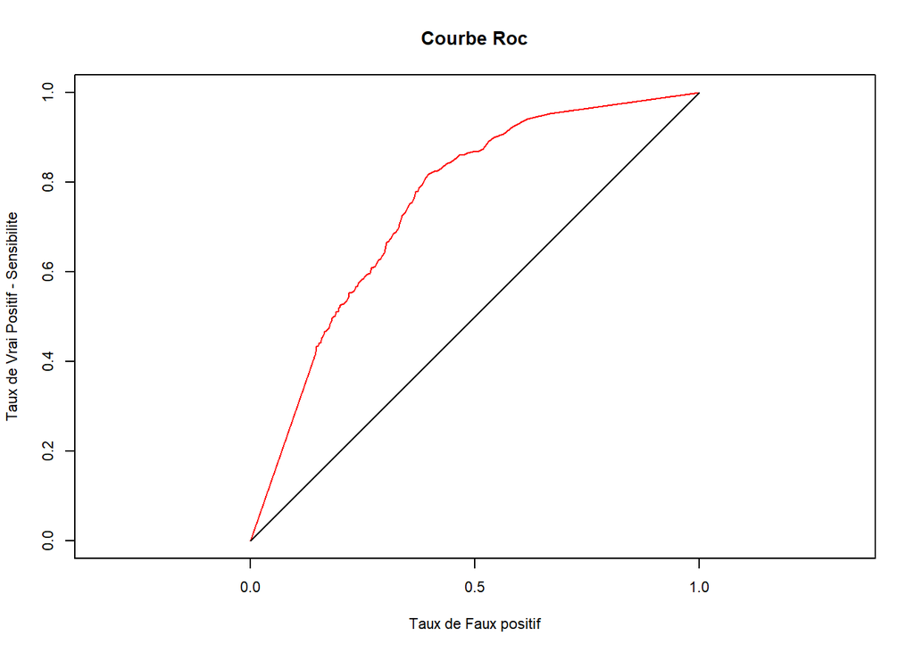

```r
par(cex=0.7)
plot(c(ErrorI_qda_T_H,0),c(1-ErrorII_qda_T_H,0),main="Courbe Roc",
ylab="Taux de Vrai Positif - Sensibilite",
xlab="Taux de Faux positif",type="l",asp=1,col="red",xlim=c(0,1),ylim=c(0,1))
segments(0,0,1,1)
```

### KNN

#### Trouvons le meilleur k avec tune :

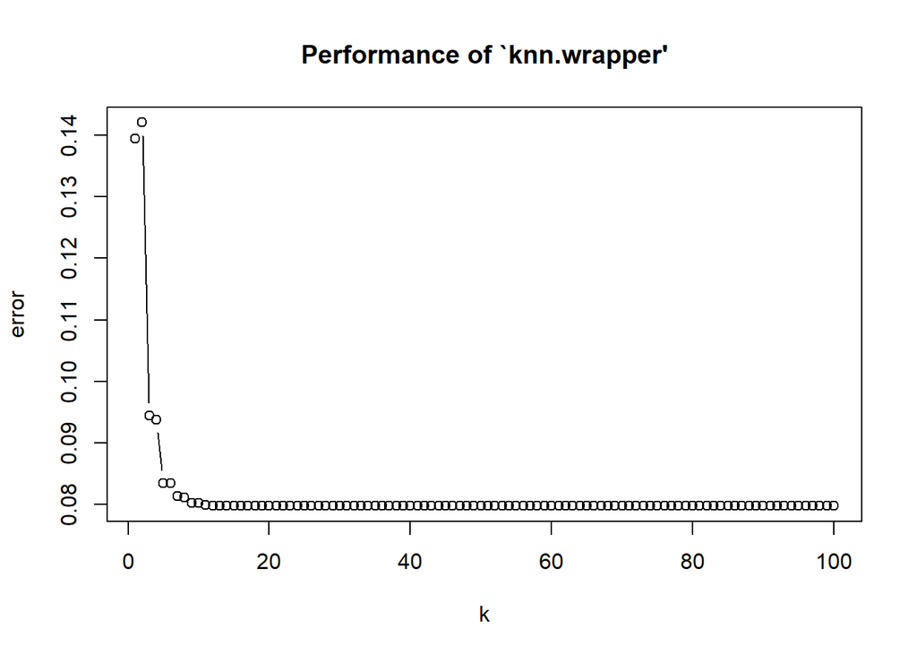

```r
knn_tune_qda_T_H <- tune.knn(x=train_data_H[,-c(1,2,5,7,14)],
                             y = train_data_H[,-c( 2,5,7,14)]$popularity,k=1:100)
plot(knn_tune_qda_T_H)
```

#### Méthode bootsrap pour estimer l’erreur de prédiction :

```r
Npop_H = nrow(train_data_H)
K <- 70
err.boot_H <- NULL
for (i in 1:100){
      boot.ind_H <- sample(1:Npop_H, Npop_H,replace=TRUE)
      test.ind_H <- setdiff(1:Npop_H, boot.ind_H)
      knn.pred_H <- knn(train = train_data_H[boot.ind_H,-c(1,2,5,7,14)], test = train_data_H[test.ind_H,-c(1,2,5,7,14)],
                      cl = train_data_H[boot.ind_H,1], k = K)
      err.boot_H[i] <- mean(train_data_H[test.ind_H,1]!=knn.pred_H)
}
```

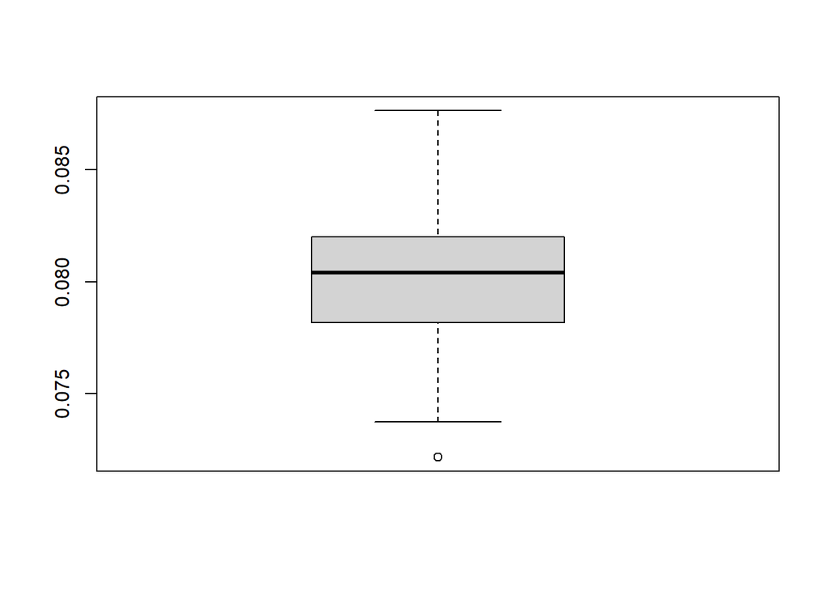

```r
boxplot(err.boot_H)
```

```r
# on fixe le nombre de voisins à considérer
K <- 70
#réalisation de la prédiction
knn_pred_qda_T_H <- knn(train = train_data_H[,-c(1,2,5,7,14)], test = valid_data_H[,-c(1,2,5,7,14)],
                cl = train_data_H[,"popularity"], k=K)
# prédiction par des probabilités
knn_pred_prob_qda_T_H <- knn(train = train_data_H[,-c(1,2,5,7,14)],
                             test = valid_data_H[,-c(1,2,5,7,14)],
                             cl = train_data_H[,"popularity"], k=K, prob = TRUE)
#matrice de confusion en test
table(valid_data_H[,1],knn_pred_qda_T_H)
```

```
##        knn_pred_qda_T_H
##         haute basse
##   haute     0   358
##   basse     0  4332
```

```r
#taux d'erreur
mean(valid_data_H[,1]!=knn_pred_qda_T_H)
```

```
## [1] 0.07633262
```

### Arbre de décision :

#### Premier arbre avec paramètres max :

```r
control_max_H <- rpart.control(cp = 0, max.depth = 0, minbucket = 1, minsplit = 1)
tree_max_H <- rpart(popularity~. , data = train_data_H, control = control_max_H,
            parms = list(split = "information"))
```

#### Estimation et élagage :

Les informations sur le paramètre de complexité s’obtient avec les commandes suivantes.

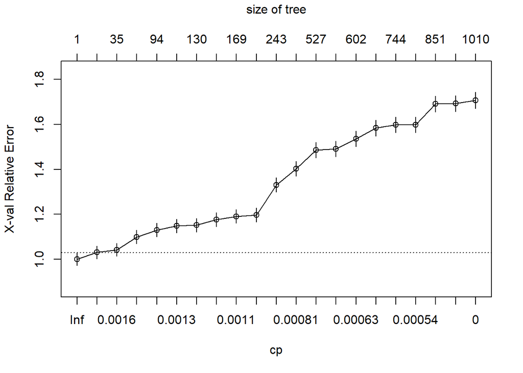

```r
plotcp(tree_max_H)
```

```r
#tree_max_H$cp
#tree_max_H$numresp
#tree_max_H$cp
```

calcul du meilleur cp :

```r
i=which.min(tree_max_H$cp[,"xerror"])
threshold_H=tree_max_H$cp[i,"xerror"]+tree_max_H$cp[i,"xstd"]
j=which(tree_max_H$cp[,"xerror"]<=threshold_H)
tree_max_H$cp[j,"CP"]%>%kable()%>%kable_styling()
```

| x |
| --- |
| 0.002139 |

On réalise “l’élagage” de l’arbre en fonction du CP retenu.

```r
tree_H<- prune(tree_max_H, cp = 0.002139037)
```

```r
Prediction_tree_H<- predict(tree_H, newdata = valid_data_H, type = "class")
```

```r
control_max_H2 <- rpart.control(cp = 0.002139037, max.depth = 0, minbucket = 1, minsplit = 1)
tree_Fin_H <- rpart(popularity~. , data = train_data_H, control = control_max_H2,
            parms = list(split = "information"))
```

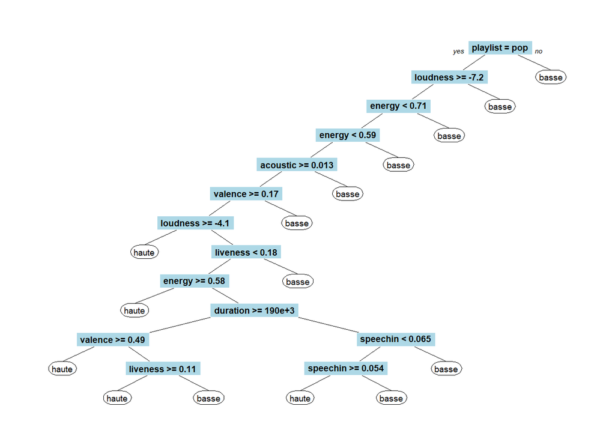

```r
prp(tree_Fin_H,type=0,extra=0,split.box.col="lightblue",cex=0.6)
```

Erreur :

```r
Realite_tree_H<-valid_data_H$popularity
MatConf_tree_H<-table(Realite_tree_H,Prediction_tree_H)
```

```r
N<-sum(valid_data_H$popularity=="basse")
P<-sum(valid_data_H$popularity=="haute")
Error_tree_H<-NULL
ErrorI_tree_H<-NULL
ErrorII_tree_H<-NULL


Error_tree_H<-sum(Prediction_tree_H!=Realite_tree_H)/nrow(valid_data_H)
ErrorI_tree_H<-sum((Prediction_tree_H=="haute")&(Realite_tree_H=="basse"))/N
ErrorII_tree_H<-sum((Prediction_tree_H=="basse")&(Realite_tree_H=="haute"))/P
```

#### Changement du seuil d’acceptation dans le groupe :

test avec méthode prob pour changer seuil d’acceptation des groupes :

```r
Prediction_tree_H_prob<- predict(tree_H, newdata = valid_data_H, type = "prob")
Prediction_tree_H<- predict(tree_H, newdata = valid_data_H, type = "class")
```

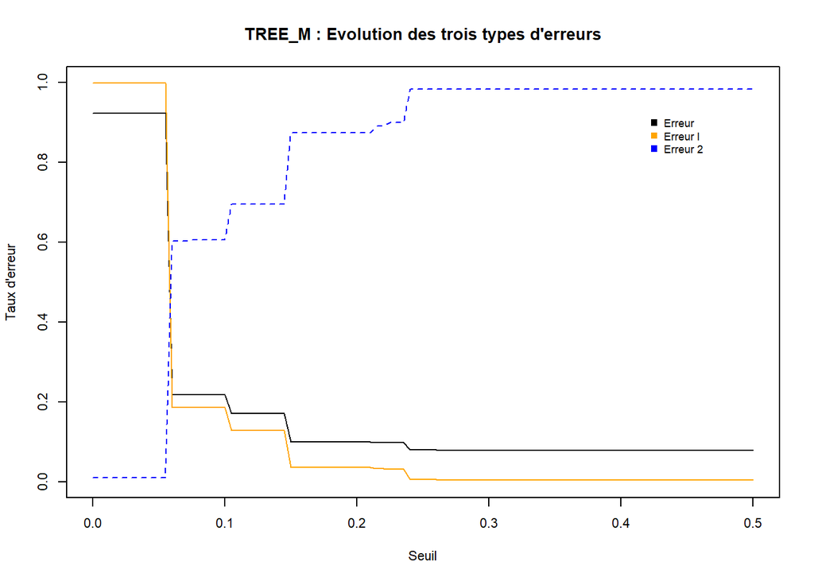

```r
N<-sum(valid_data_H=="basse")
P<-sum(valid_data_H=="haute")
Error_tree_H<-NULL
ErrorI_tree_H<-NULL
ErrorII_tree_H<-NULL
for(i in 1:101){
c<-(i-1)/200
Prediction_tree_HS<-rep("basse",nrow(valid_data_H))
Prediction_tree_HS[Prediction_tree_H_prob[,1]>c]<-"haute"
Error_tree_H[i]<-sum(Prediction_tree_HS!=Realite_lda_T_H)/nrow(valid_data_H)
ErrorI_tree_H[i]<-sum((Prediction_tree_HS=="haute")&(Realite_lda_T_H=="basse"))/N
ErrorII_tree_H[i]<-sum((Prediction_tree_HS=="basse")&(Realite_lda_T_H=="haute"))/P
}
par(cex=0.7)
plot((0:100)/200,Error_tree_H,type="l",xlim=c(0,0.5),ylim=c(0,1),
ylab="Taux d'erreur",xlab="Seuil")
par(new=T)
plot((0:100)/200,ErrorI_tree_H,type="l",xlim=c(0,0.5),ylim=c(0,1),
ylab="",xlab="",xaxt="n",yaxt="n",col="orange")
par(new=T)
plot((0:100)/200,ErrorII_tree_H,type="l",xlim=c(0,0.5),ylim=c(0,1),ylab="",xlab="",xaxt="n",yaxt="n",col="blue",lty="dashed")
legend('topright', legend=c("Erreur ", "Erreur I", "Erreur 2"),
       col=c("black","orange", "blue"), pch=15, bty="n", pt.cex=1, cex= 0.8, horiz=FALSE, inset=c(0.1,0.1))
title("TREE_M : Evolution des trois types d'erreurs")
```

Choix du seuil :

```r
change_seuil_tree_H<-rep("basse",nrow(valid_data_H))
change_seuil_tree_H[Prediction_tree_H_prob[,1]>0.07]<-"haute"
MatConf_tree_H2<-table(Realite_qda_T_H,change_seuil_tree_H)
round(prop.table(table(Realite_qda_T_H,Prediction_tree_H),margin=1)*100,1)%>%kable(caption = "TREE_H : matrice de confusion seuil 0,05")%>% kable_styling()
```

|  | haute | basse |
| --- | --- | --- |
| haute | 1.7 | 98.3 |
| basse | 0.5 | 99.5 |

```r
round(prop.table(table(Realite_qda_T_H,change_seuil_tree_H),margin=1)*100,1)%>%kable(caption = "TREE_H : matrice de confusion seuil 0,17")%>% kable_styling()
```

|  | basse | haute |
| --- | --- | --- |
| haute | 60.3 | 39.7 |
| basse | 81.3 | 18.7 |

```r
N<-sum(valid_data_H=="basse")
P<-sum(valid_data_H=="haute")

Error_tree_H1<-sum(Prediction_tree_H!=Realite_lda_T_H)/nrow(valid_data_H)
ErrorI_tree_H1<-sum((Prediction_tree_H=="haute")&(Realite_lda_T_H=="basse"))/N
ErrorII_tree_H1<-sum((Prediction_tree_H=="basse")&(Realite_lda_T_H=="haute"))/P

Error_tree_H<-sum(change_seuil_tree_H!=Realite_lda_T_H)/nrow(valid_data_H)
ErrorI_tree_H<-sum((change_seuil_tree_H=="haute")&(Realite_lda_T_H=="basse"))/N
ErrorII_tree_H<-sum((change_seuil_tree_H=="basse")&(Realite_lda_T_H=="haute"))/P

matrix_error_tree_H <- as.table(matrix(round(c(Error_tree_H1, Error_tree_H, ErrorI_tree_H1, ErrorI_tree_H, ErrorII_tree_H1, ErrorII_tree_H),3), ncol = 3, nrow = 2))
rownames(matrix_error_tree_H)<- c("seuil= 0,5", "seuil= 0,07 ")
colnames(matrix_error_tree_H)<- c("Erreur", "Erreur1", "Erreur2")

kable(matrix_error_tree_H, caption = "comparaison des erreurs") %>% kable_styling()
```

comparaison des erreurs

|  | Erreur | Erreur1 | Erreur2 |
| --- | --- | --- | --- |
| seuil= 0,5 | 0.079 | 0.005 | 0.983 |
| seuil= 0,07 | 0.219 | 0.187 | 0.603 |

### Random Forest

#### Choix des meilleurs paramètres :

choix des meilleurs min.no.size et mtry avec caret :

```r
ctrlCv <- trainControl(method = "repeatedcv", repeats = 3)
rangerGrid_H <- expand.grid(mtry = c(1, 2, 4, 8, 12), min.node.size = c(10, 50, 100, 150), splitrule = "gini")
# enregistrement d'un cluster avec le package doParallel
library(doParallel)
registerDoParallel(cores = 6)
# lancement de la commande à l'identique
system.time(ranger.caret_H <- train(popularity ~ .,
  data = train_data_H, method = "ranger",
  trControl = ctrlCv, tuneGrid = rangerGrid_H
))
```

```
##    user  system elapsed
##   26.83    0.48 1258.40
```

```r
# fermeture du cluster
stopImplicitCluster()
```

```r
ranger.caret_H$bestTune%>%kable()%>%kable_styling()
```

|  | mtry | splitrule | min.node.size |
| --- | --- | --- | --- |
| 13 | 8 | gini | 10 |

Choix profondeur et nb d’arbres :

```r
set.seed((1))
nvar=ncol(data_pop_H)-1
err_par_H <- NULL
prof <- c(20,40,60,80,100, 200)
profondeur<-c(200,300,400,500)
i <- 1
for (k in prof){
  for (l in profondeur){
  rfpro_par_H <- randomForest(popularity ~ .,
    data = train_data_H,mtry=12, method = "class", ntree = l,
    parms = list(split = "gini"), maxnodes = k, min.nodesize=10
  )
  err_par_H[i] <- rfpro_par_H$err.rate[l, 1]
  i <- i + 1
}}

tabloH <-as.table(matrix(err_par_H,nrow=4, byrow=FALSE))
colnames(tabloH)<-prof
row.names(tabloH) <- profondeur
tabloH%>% kable()%>% kable_styling()
```

|  | 20 | 40 | 60 | 80 | 100 | 200 |
| --- | --- | --- | --- | --- | --- | --- |
| 200 | 0.0798920 | 0.0797498 | 0.0798920 | 0.0798920 | 0.0796076 | 0.0796076 |
| 300 | 0.0798209 | 0.0797498 | 0.0798920 | 0.0798920 | 0.0798209 | 0.0796076 |
| 400 | 0.0798920 | 0.0797498 | 0.0798920 | 0.0798920 | 0.0799630 | 0.0798920 |
| 500 | 0.0798209 | 0.0798209 | 0.0798209 | 0.0798209 | 0.0798920 | 0.0798920 |

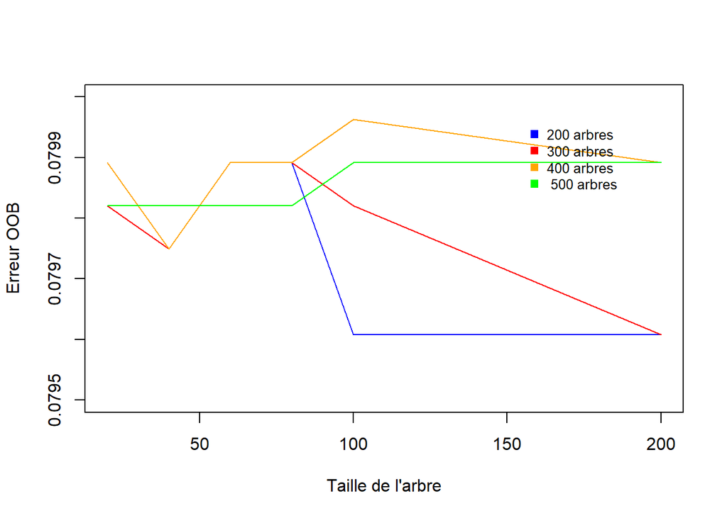

```r
plot(prof,tabloH[1,],type="l",col="blue", xlab = "Taille de l'arbre", ylab="Erreur OOB",ylim=c(0.0795,0.08))
lines(prof,tabloH[2,],col="red")
lines(prof,tabloH[3,],col="orange")
lines(prof,tabloH[4,],col="green")
legend('topright', legend=c("200 arbres", "300 arbres", "400 arbres", " 500 arbres"),
col=c("blue", "red", "orange", "green"), pch=15, bty="n", pt.cex=1, cex= 0.8, horiz=FALSE, inset=c(0.1,0.1))
```

```r
rf_H <- randomForest(popularity ~ .,
  data = train_data_H, method = "class", mtry=12, method = "class", ntree = 200,
    parms = list(split = "gini"), maxnodes = 200, min.nodesize=10, na.action = na.roughfix
)
```

#### graphiques des erreurs en fonctions de certains paramètres :

Grapgiques pour tester les paramètres.

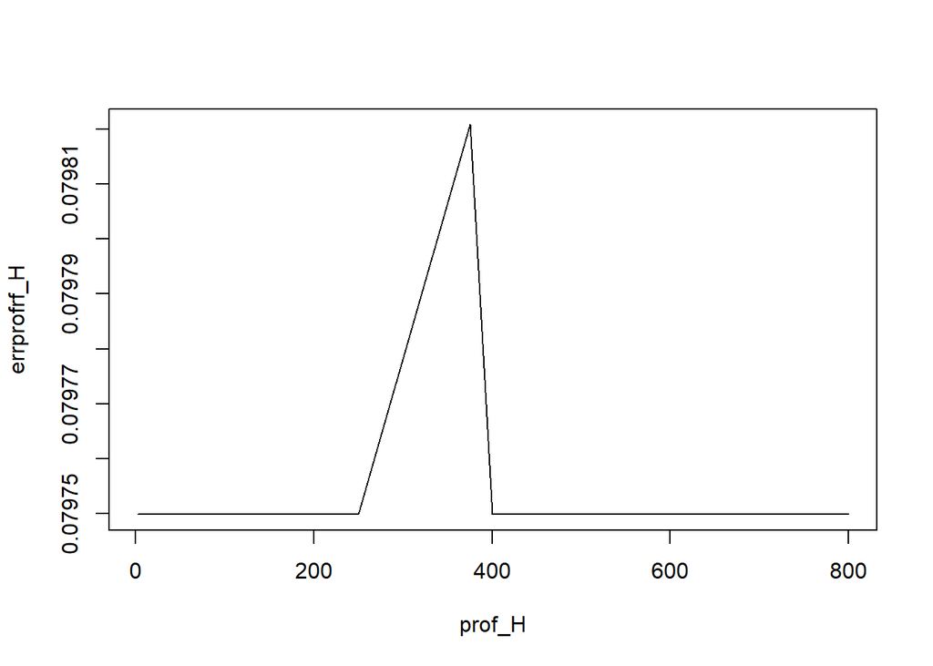

```r
# trouver le meilleur maxnodes
errprofrf_H <- NULL
prof_H <- c(2, 5, 10, 15, 20, 30, 40, 50, 75, 100, 150, 250, 375, 400, 600, 800)
i <- 1
for (k in prof_H) {
  rfpro_H <- randomForest(popularity ~ .,
    data = train_data_H, method = "class", ntree = 200, mytry = 12,
    parms = list(split = "gini"), maxnodes = k, na.action = na.roughfix
  )
  errprofrf_H[i] <- rfpro_H$err.rate[200, 1]
  i <- i + 1
}
plot(prof_H, errprofrf_H, type = "l")
```

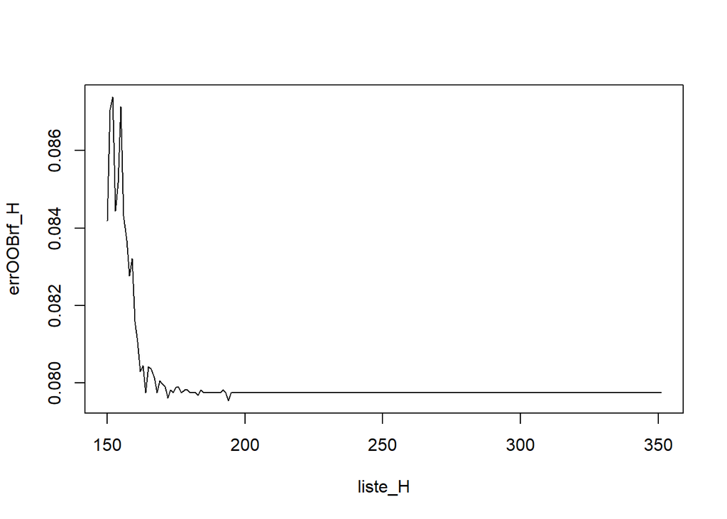

```r
#trouver le meilleur nb d'arbres (ntree)
errOOBrf_H <- NULL
i <- 1
liste_H = c(150:351)
for (k in liste_H ) {
  rf1_H <- randomForest(popularity ~ .,
    data = train_data_H, method = "class", ntree = k,
    parms = list(split = "gini"), maxnodes = 100, na.action = na.roughfix
  )
  errOOBrf_H[i] <- rf1_H$err.rate[i, 1]
  i <- i + 1
}
plot(liste_H, errOOBrf_H, type = "l")
```

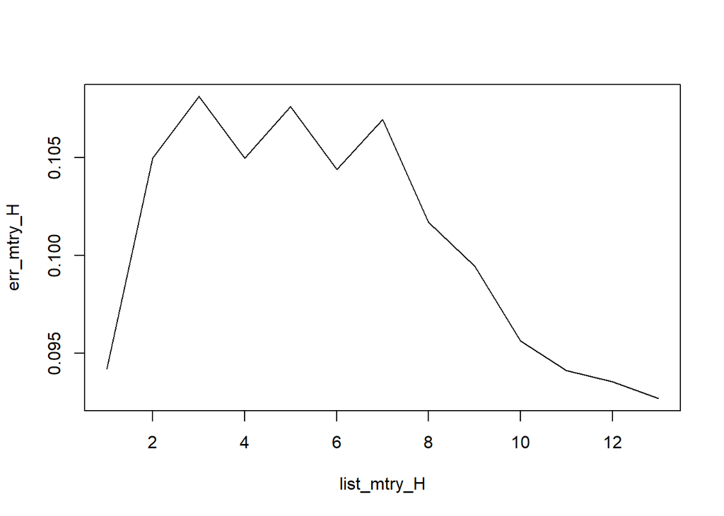

```r
# trouver le meilleur mtry :

err_mtry_H <- NULL
list_mtry_H = c(1:13)
i <- 1
for (k in list_mtry_H) {
  rf_mtry_H <- randomForest(popularity ~ .,
    data = train_data_H, method = "class", ntree = 250,
    parms = list(split = "gini"), maxnodes = 400, mtry = k, na.action = na.roughfix
  )

  err_mtry_H[i] <- rf_mtry_H$err.rate[i, 1]
  i <- i + 1
}
plot(list_mtry_H, err_mtry_H, type = "l")
```

#### Changement du seuil d’acceptation :

```r
prediction_rf_H<- predict(rf_H, newdata = valid_data_H, type = "class")
```

test avec méthode prob pour changer seuil d’acceptation des groupes :

```r
Prediction_rf_H_prob<- predict(rf_H, newdata = valid_data_H, type = "prob")
```

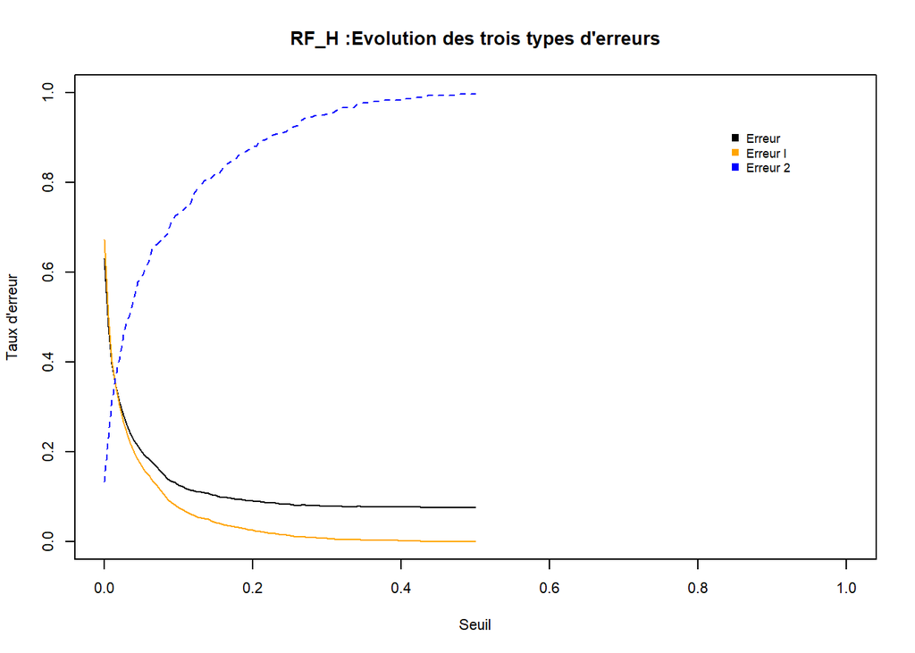

```r
N<-sum(valid_data_H=="basse")
P<-sum(valid_data_H=="haute")
Error_rf_H<-NULL
ErrorI_rf_H<-NULL
ErrorII_rf_H<-NULL
for(i in 1:101){
c<-(i-1)/200
Prediction_rf_HS<-rep("basse",nrow(valid_data_H))
Prediction_rf_HS[Prediction_rf_H_prob[,1]>c]<-"haute"
Error_rf_H[i]<-sum(Prediction_rf_HS!=Realite_lda_T_H)/nrow(valid_data_H)
ErrorI_rf_H[i]<-sum((Prediction_rf_HS=="haute")&(Realite_lda_T_H=="basse"))/N
ErrorII_rf_H[i]<-sum((Prediction_rf_HS=="basse")&(Realite_lda_T_H=="haute"))/P
}
par(cex=0.7)
plot((0:100)/200,Error_rf_H,type="l",xlim=c(0,1),ylim=c(0,1),
ylab="Taux d'erreur",xlab="Seuil")
par(new=T)
plot((0:100)/200,ErrorI_rf_H,type="l",xlim=c(0,1),ylim=c(0,1),
ylab="",xlab="",xaxt="n",yaxt="n",col="orange")
par(new=T)
plot((0:100)/200,ErrorII_rf_H,type="l",xlim=c(0,1),ylim=c(0,1),ylab="",xlab="",xaxt="n",yaxt="n",col="blue",lty="dashed")
legend('topright', legend=c("Erreur ", "Erreur I", "Erreur 2"),
       col=c("black","orange", "blue"), pch=15, bty="n", pt.cex=1, cex= 0.8, horiz=FALSE, inset=c(0.1,0.1))
title("RF_H :Evolution des trois types d'erreurs")
```

On choisit un seuil en réalisant un arbitrage entre erreur globale et erreur de type 2 acceptable.

```r
round(prop.table(table(Realite_lda_T_H,prediction_rf_H),margin=1)*100,1)%>% kable(caption = "RF_H : matrice de confusion seuil 0,5")%>%kable_styling()
```

RF_H : matrice de confusion seuil 0,5

|  | haute | basse |
| --- | --- | --- |
| haute | 0.3 | 99.7 |
| basse | 0.0 | 100.0 |

```r
change_seuil_rf_H<-rep("basse",nrow(valid_data_H))
change_seuil_rf_H[Prediction_rf_H_prob[,1]>0.05]<-"haute"
MatConf_rf_H2<-table(Realite_lda_T_H,change_seuil_rf_H)
round(prop.table(table(Realite_lda_T_H,change_seuil_rf_H),margin=1)*100,1)%>% kable(caption = "RF_H : matrice de confusion seuil 0,05")%>%kable_styling()
```

RF_H : matrice de confusion seuil 0,05

|  | basse | haute |
| --- | --- | --- |
| haute | 58.9 | 41.1 |
| basse | 83.1 | 16.9 |

```r
N<-sum(valid_data_H=="basse")
P<-sum(valid_data_H=="haute")

ex_extreme<-round(prop.table(table(Realite_lda_T_H,prediction_rf_H),margin=1)*100,1)
Error_rf_H1<-sum(prediction_rf_H!=Realite_lda_T_H)/nrow(valid_data_H)
ErrorI_rf_H1<-sum((prediction_rf_H=="haute")&(Realite_lda_T_H=="basse"))/N
ErrorII_rf_H1<-sum((prediction_rf_H=="basse")&(Realite_lda_T_H=="haute"))/P

Error_rf_H<-sum(change_seuil_rf_H!=Realite_lda_T_H)/nrow(valid_data_H)
ErrorI_rf_H<-sum((change_seuil_rf_H=="haute")&(Realite_lda_T_H=="basse"))/N
ErrorII_rf_H<-sum((change_seuil_rf_H=="basse")&(Realite_lda_T_H=="haute"))/P


matrix_error_rf_H <- as.table(matrix(round(c(Error_rf_H1, Error_rf_H, ErrorI_rf_H1, ErrorI_rf_H, ErrorII_rf_H1, ErrorII_rf_H),3), ncol = 3, nrow = 2))
rownames(matrix_error_rf_H)<- c("seuil= 0,5", "seuil= 0,05")
colnames(matrix_error_rf_H)<- c("Erreur", "Erreur1", "Erreur2")

kable(matrix_error_rf_H, caption = "comparaison des erreurs") %>% kable_styling()
```

comparaison des erreurs

|  | Erreur | Erreur1 | Erreur2 |
| --- | --- | --- | --- |
| seuil= 0,5 | 0.076 | 0.000 | 0.997 |
| seuil= 0,05 | 0.201 | 0.169 | 0.589 |

### Comparaison entre les différents types de modèle :

On a selectionné lda_H_seuil07, qda_H_seuil17, tree_H_seuil07 et rf_H_seuil05.

Comparons les différents modèles à l’aide des données test.

```r
N<-sum(test_data_H=="basse")
P<-sum(test_data_H=="haute")
res_lda_seuil_H<-predict(lda_T_H,newdata=test_data_H, type ="prob")
Prediction_H_seuilLDA<-rep("basse",nrow(test_data_H))
Prediction_H_seuilLDA[res_lda_seuil_H$posterior[,1]>0.07]<-"haute"
Error_lda_seuil_H<-sum(Prediction_H_seuilLDA!=test_data_H$popularity)/nrow(test_data_H)
ErrorI_lda_seuil_H<-sum((Prediction_H_seuilLDA=="haute")&(test_data_H$popularity=="basse"))/N
ErrorII_lda_seuil_H<-sum((Prediction_H_seuilLDA=="basse")&(test_data_H$popularity=="haute"))/P
```

```r
N<-sum(test_data_H=="basse")
P<-sum(test_data_H=="haute")
res_qda_seuil_H<-predict(qda_T_H,newdata=test_data_H)
Prediction_H_seuilQDA<-rep("basse",nrow(test_data_H))
Prediction_H_seuilQDA[res_qda_seuil_H$posterior[,1]>0.17]<-"haute"
Error_qda_seuil_H<-sum(res_qda_seuil$class!=test_data_H$popularity)/nrow(test_data_H)
ErrorI_qda_seuil_H<-sum((res_qda_seuil$class=="haute")&(test_data_H$popularity=="basse"))/N
ErrorII_qda_seuil_H<-sum((res_qda_seuil$class=="basse")&(test_data_H$popularity=="haute"))/P
```

```r
N<-sum(test_data_H=="basse")
P<-sum(test_data_H=="haute")
best_rpart_control_H <- rpart.control(cp = 0.002139037, max.depth = 0,
                              minbucket = 1, minsplit = 1)
best_tree_H <- rpart(popularity ~ .,
  data = train_data_H, control = best_rpart_control_H,
  parms = list(split = "information")
)

res_best_tree_H<-predict(best_tree_H,newdata=test_data_H, type = "prob")
Prediction_H_seuilTREE<-rep("basse",nrow(test_data_H))
Prediction_H_seuilTREE[res_best_tree_H[,1]>0.07]<-"haute"
Error_best_tree_H<-sum(Prediction_H_seuilTREE!=test_data_H$popularity)/nrow(test_data_H)
ErrorI_best_tree_H<-sum((Prediction_H_seuilTREE=="haute")&(test_data_H$popularity=="basse"))/N
ErrorII_best_tree_H<-sum((Prediction_H_seuilTREE=="basse")&(test_data_H$popularity=="haute"))/P
```

```r
N<-sum(test_data_H=="basse")
P<-sum(test_data_H=="haute")
best_rf_H <-randomForest(popularity ~ .,
                         data = train_data_H, method = "class", mtry=12, method = "class", ntree = 200,
                         parms = list(split = "gini"), maxnodes = 200, min.nodesize=10, na.action = na.roughfix
)

res_best_rf_H<-predict(best_rf_H,newdata=test_data_H, type ="prob")
Prediction_H_seuilRF<-rep("basse",nrow(test_data_H))
Prediction_H_seuilRF[res_best_rf_H[,1]>0.05]<-"haute"
Error_best_rf_H<-sum(Prediction_H_seuilRF!=test_data_H$popularity)/nrow(test_data_H)
ErrorI_best_rf_H<-sum((Prediction_H_seuilRF=="haute")&(test_data_H$popularity=="basse"))/N
ErrorII_best_rf_H<-sum((Prediction_H_seuilRF=="basse")&(test_data_H$popularity=="haute"))/P
```

```r
erreursH <- matrix(c(Error_lda_seuil_H, Error_qda_seuil_H, Error_best_tree_H, Error_best_rf_H,
                    ErrorI_lda_seuil_H, ErrorI_qda_seuil_H, ErrorI_best_tree_H, ErrorI_best_rf_H,
                    ErrorII_lda_seuil_H, ErrorII_qda_seuil_H, ErrorII_best_tree_H, ErrorII_best_rf_H), byrow = FALSE, ncol = 3)
colnames(erreursH) <- c("Erreur globale", "Erreur type I", "Erreur type 2")
rownames(erreursH) <- c("lda07", "qda17", "tree07", "rf05")
erreursH %>% knitr::kable(digits = 3) %>%
  kableExtra::kable_styling()
```

|  | Erreur globale | Erreur type I | Erreur type 2 |
| --- | --- | --- | --- |
| lda07 | 0.357 | 0.363 | 0.294 |
| qda17 | 0.415 | 0.437 | 0.189 |
| tree07 | 0.216 | 0.176 | 0.632 |
| rf05 | 0.209 | 0.171 | 0.608 |